# Quadratures

Piotr Król

28 06 2021

Content:

- ltm
  - 15 quadratures
  - 61 quadratures
  - 101 quadratures
- mirt
  - 15 quadratures
  - 61 quadratures
  - 151 quadratures
  - 151 quadratures with increased max number of cycles
  - 301 quadratures
  - 301 quadratures with increased max number of cycles
  - 451 quadratures
  - 601 quadratures
- summary mirt
  - differences in mirt’s logLik wrt quadratures
  - differences in mirt’s 1st item param wrt quadratures
- TAM
  - default settings (quasi Monte Carlo integration)
  - 201 snodes (“ordinary” stochastic integration)
  - 301 snodes
  - 451 snodes
- summary tables

```r
library(ltm)
library(mirt)
library(TAM)
library(ggpubr)
library(beepr)
```

```r
responses_demo <- read.csv("Data/responses_demo.csv", encoding = "UTF-8")
responses <- as.matrix(responses_demo[,5:ncol(responses_demo)])
```

## *ltm*

### *ltm* with default 15 quadrature points

```r
ltm_model <- ltm(responses ~ z1, IRT.param = FALSE)
```

```r
summary(ltm_model)$logLik
```

```
## [1] -470030.7
```

```r
ltm_params <- as.data.frame(coef(ltm_model))
head(ltm_params)
```

```
##       (Intercept)        z1
## item1   0.5007685 0.5062726
## item2   3.0325412 0.6000710
## item3   2.2231741 0.5203958
## item4   1.6207654 0.6342804
## item5   2.9181067 0.6132288
## item6   1.7540911 0.5503886
```

### *ltm* with 61 quadrature points

```r
ltm_model <- ltm(responses ~ z1, IRT.param = FALSE, control = list(GHk = 61))
```

```r
summary(ltm_model)$logLik
```

```
## [1] -466025.8
```

```r
ltm_params <- as.data.frame(coef(ltm_model))
head(ltm_params)
```

```
##       (Intercept)        z1
## item1   0.3814645 0.6275291
## item2   2.8976562 0.7364706
## item3   2.1075957 0.6449390
## item4   1.4706989 0.7844162
## item5   2.7759578 0.7517544
## item6   1.6228791 0.6774569
```

### *ltm* with 101 quadrature points

Higher number (111) is not possible. It gives error ‘Błąd w poleceniu ’gh[[n]]’:indeks jest poza granicami’

```r
# I also increased number of iterations to make it the same as mirt had with 301 quadratures
ltm_model <- ltm(responses ~ z1, IRT.param = FALSE, control = list(iter.em = 2084, GHk = 101))
```

```r
summary(ltm_model)$logLik
```

```
## [1] -464945.3
```

```r
ltm_params <- as.data.frame(coef(ltm_model))
head(ltm_params)
```

```
##       (Intercept)        z1
## item1   0.4936673 0.6853855
## item2   3.0198061 0.7961443
## item3   2.2226354 0.7026859
## item4   1.6115438 0.8575204
## item5   2.9063334 0.8162588
## item6   1.7448760 0.7397492
```

## *mirt*

### *mirt* with 15 quadrature points

```r
mirt_model <- mirt(responses, 1, SE=TRUE, quadpts = 15)
```

```r
mirt_model
```

```
##
## Call:
## mirt(data = responses, model = 1, SE = TRUE, quadpts = 15)
##
## Full-information item factor analysis with 1 factor(s).
## Converged within 1e-04 tolerance after 72 EM iterations.
## mirt version: 1.33.2
## M-step optimizer: BFGS
## EM acceleration: Ramsay
## Number of rectangular quadrature: 15
## Latent density type: Gaussian
##
## Information matrix estimated with method: Oakes
## Second-order test: model is a possible local maximum
## Condition number of information matrix =  208.2854
##
## Log-likelihood = -472591.2
## Estimated parameters: 1340
## AIC = 947862.4; AICc = 951621.7
## BIC = 955553.1; SABIC = 951295.7
## G2 (9999998660) = 910092.4, p = 1
## RMSEA = 0, CFI = NaN, TLI = NaN
```

```r
mirt_params <- as.data.frame(coef(mirt_model, simplify = TRUE)$items)[1:2]
head(mirt_params)
```

```
##              a1        d
## item1 0.4430672 0.460863
## item2 0.5269768 2.979918
## item3 0.4586273 2.183469
## item4 0.5592089 1.577149
## item5 0.5469930 2.883802
## item6 0.4846387 1.713435
```

### *mirt* with default 61 quadrature points

```r
mirt_model <- mirt(responses, 1, SE=TRUE)
```

```r
mirt_model
```

```
##
## Call:
## mirt(data = responses, model = 1, SE = TRUE)
##
## Full-information item factor analysis with 1 factor(s).
## Converged within 1e-04 tolerance after 266 EM iterations.
## mirt version: 1.33.2
## M-step optimizer: BFGS
## EM acceleration: Ramsay
## Number of rectangular quadrature: 61
## Latent density type: Gaussian
##
## Information matrix estimated with method: Oakes
## Second-order test: model is a possible local maximum
## Condition number of information matrix =  122.3066
##
## Log-likelihood = -463630.5
## Estimated parameters: 1340
## AIC = 929941.1; AICc = 933700.3
## BIC = 937631.8; SABIC = 933374.4
## G2 (9999998660) = 892171.1, p = 1
## RMSEA = 0, CFI = NaN, TLI = NaN
```

```r
mirt_params <- as.data.frame(coef(mirt_model, simplify = TRUE)$items)[1:2]
head(mirt_params)
```

```
##              a1         d
## item1 0.9245075 0.3186796
## item2 1.0418570 2.8053719
## item3 0.9356348 2.0431438
## item4 1.1520000 1.3897563
## item5 1.0675449 2.6838458
## item6 0.9863041 1.5528866
```

### *mirt* with 151 quadrature points

```r
mirt_model <- mirt(responses, 1, SE=TRUE, quadpts = 151)
beep(sound=8)
```

```r
mirt_model
```

```
##
## Call:
## mirt(data = responses, model = 1, SE = TRUE, quadpts = 151)
##
## Full-information item factor analysis with 1 factor(s).
## FAILED TO CONVERGE within 1e-04 tolerance after 500 EM iterations.
## mirt version: 1.33.2
## M-step optimizer: BFGS
## EM acceleration: Ramsay
## Number of rectangular quadrature: 151
## Latent density type: Gaussian
##
## Information matrix estimated with method: Oakes
## Second-order test: model is a possible local maximum
## Condition number of information matrix =  551.4105
##
## Log-likelihood = -462897.1
## Estimated parameters: 1340
## AIC = 928474.1; AICc = 932233.4
## BIC = 936164.9; SABIC = 931907.4
## G2 (9999998660) = 890704.2, p = 1
## RMSEA = 0, CFI = NaN, TLI = NaN
```

```r
mirt_params <- as.data.frame(coef(mirt_model, simplify = TRUE)$items)[1:2]
head(mirt_params)
```

```
##             a1         d
## item1 1.165334 0.2498002
## item2 1.285791 2.7190547
## item3 1.166144 1.9713555
## item4 1.446802 1.3019286
## item5 1.323765 2.5984700
## item6 1.233100 1.4775154
```

### *mirt* with 151 quadrature points and 3000 max number of cycles

```r
mirt_model <- mirt(responses, 1, SE=TRUE, quadpts = 151, technical=list(NCYCLES=3000))
beep(sound=8)
```

```r
mirt_model
```

```
##
## Call:
## mirt(data = responses, model = 1, SE = TRUE, quadpts = 151, technical = list(NCYCLES = 3000))
##
## Full-information item factor analysis with 1 factor(s).
## Converged within 1e-04 tolerance after 931 EM iterations.
## mirt version: 1.33.2
## M-step optimizer: BFGS
## EM acceleration: Ramsay
## Number of rectangular quadrature: 151
## Latent density type: Gaussian
##
## Information matrix estimated with method: Oakes
## Second-order test: model is a possible local maximum
## Condition number of information matrix =  565.0109
##
## Log-likelihood = -462896.9
## Estimated parameters: 1340
## AIC = 928473.8; AICc = 932233.1
## BIC = 936164.6; SABIC = 931907.1
## G2 (9999998660) = 890703.9, p = 1
## RMSEA = 0, CFI = NaN, TLI = NaN
```

```r
mirt_params <- as.data.frame(coef(mirt_model, simplify = TRUE)$items)[1:2]
head(mirt_params)
```

```
##             a1         d
## item1 1.169939 0.2477076
## item2 1.290645 2.7165786
## item3 1.170636 1.9691582
## item4 1.452705 1.2990132
## item5 1.328800 2.5959273
## item6 1.238176 1.4749281
```

### *mirt* with 301 quadrature points

```r
mirt_model <- mirt(responses, 1, SE=TRUE, quadpts = 301)
```

```r
mirt_model
```

```
##
## Call:
## mirt(data = responses, model = 1, SE = TRUE, quadpts = 301)
##
## Full-information item factor analysis with 1 factor(s).
## FAILED TO CONVERGE within 1e-04 tolerance after 500 EM iterations.
## mirt version: 1.33.2
## M-step optimizer: BFGS
## EM acceleration: Ramsay
## Number of rectangular quadrature: 301
## Latent density type: Gaussian
##
## Information matrix estimated with method: Oakes
## Second-order test: model is a possible local maximum
## Condition number of information matrix =  1718.137
##
## Log-likelihood = -462864.2
## Estimated parameters: 1340
## AIC = 928408.4; AICc = 932167.7
## BIC = 936099.2; SABIC = 931841.8
## G2 (9999998660) = 890638.5, p = 1
## RMSEA = 0, CFI = NaN, TLI = NaN
```

```r
mirt_params <- as.data.frame(coef(mirt_model, simplify = TRUE)$items)[1:2]
head(mirt_params)
```

```
##             a1         d
## item1 1.213362 0.3500305
## item2 1.336839 2.8292969
## item3 1.213555 2.0718516
## item4 1.506946 1.4265899
## item5 1.375826 2.7115204
## item6 1.283309 1.5832894
```

### *mirt* with 301 quadrature points and 3000 max number of cycles

```r
mirt_model <- mirt(responses, 1, SE=TRUE, quadpts = 301, technical=list(NCYCLES=3000))
```

```r
mirt_model
```

```
##
## Call:
## mirt(data = responses, model = 1, SE = TRUE, quadpts = 301, technical = list(NCYCLES = 3000))
##
## Full-information item factor analysis with 1 factor(s).
## Converged within 1e-04 tolerance after 2084 EM iterations.
## mirt version: 1.33.2
## M-step optimizer: BFGS
## EM acceleration: Ramsay
## Number of rectangular quadrature: 301
## Latent density type: Gaussian
##
## Information matrix estimated with method: Oakes
## Second-order test: model is a possible local maximum
## Condition number of information matrix =  2241.498
##
## Log-likelihood = -462860.8
## Estimated parameters: 1340
## AIC = 928401.5; AICc = 932160.8
## BIC = 936092.2; SABIC = 931834.8
## G2 (9999998660) = 890631.6, p = 1
## RMSEA = 0, CFI = NaN, TLI = NaN
```

```r
mirt_params <- as.data.frame(coef(mirt_model, simplify = TRUE)$items)[1:2]
head(mirt_params)
```

```
##             a1         d
## item1 1.230405 0.4002519
## item2 1.355571 2.8845418
## item3 1.230727 2.1220920
## item4 1.528554 1.4891014
## item5 1.395263 2.7684442
## item6 1.301493 1.6364191
```

So clearly it’s worth to increase maximum number of cycles.

### *mirt* with 451 quadrature points

```r
mirt_model <- mirt(responses, 1, SE=TRUE, quadpts = 451, technical=list(NCYCLES=3000))
```

```r
mirt_model
```

```
##
## Call:
## mirt(data = responses, model = 1, SE = TRUE, quadpts = 451, technical = list(NCYCLES = 3000))
##
## Full-information item factor analysis with 1 factor(s).
## Converged within 1e-04 tolerance after 2225 EM iterations.
## mirt version: 1.33.2
## M-step optimizer: BFGS
## EM acceleration: Ramsay
## Number of rectangular quadrature: 451
## Latent density type: Gaussian
##
## Information matrix estimated with method: Oakes
## Second-order test: model is a possible local maximum
## Condition number of information matrix =  2311.071
##
## Log-likelihood = -462860.7
## Estimated parameters: 1340
## AIC = 928401.4; AICc = 932160.7
## BIC = 936092.1; SABIC = 931834.7
## G2 (9999998660) = 890631.4, p = 1
## RMSEA = 0, CFI = NaN, TLI = NaN
```

```r
mirt_params <- as.data.frame(coef(mirt_model, simplify = TRUE)$items)[1:2]
head(mirt_params)
```

```
##             a1         d
## item1 1.231039 0.4041335
## item2 1.356301 2.8888244
## item3 1.231385 2.1259856
## item4 1.529381 1.4939411
## item5 1.396010 2.7728479
## item6 1.302184 1.6405313
```

### *mirt* with 601 quadrature points

```r
mirt_model <- mirt(responses, 1, SE=TRUE, quadpts = 601, technical=list(NCYCLES=10000))
```

```r
mirt_model
```

```
##
## Call:
## mirt(data = responses, model = 1, SE = TRUE, quadpts = 601, technical = list(NCYCLES = 10000))
##
## Full-information item factor analysis with 1 factor(s).
## Converged within 1e-04 tolerance after 2652 EM iterations.
## mirt version: 1.33.2
## M-step optimizer: BFGS
## EM acceleration: Ramsay
## Number of rectangular quadrature: 601
## Latent density type: Gaussian
##
## Information matrix estimated with method: Oakes
## Second-order test: model is a possible local maximum
## Condition number of information matrix =  2310.672
##
## Log-likelihood = -462860.7
## Estimated parameters: 1340
## AIC = 928401.3; AICc = 932160.6
## BIC = 936092.1; SABIC = 931834.6
## G2 (9999998660) = 890631.4, p = 1
## RMSEA = 0, CFI = NaN, TLI = NaN
```

```r
mirt_params <- as.data.frame(coef(mirt_model, simplify = TRUE)$items)[1:2]
head(mirt_params)
```

```
##             a1        d
## item1 1.231205 0.405889
## item2 1.356512 2.890774
## item3 1.231575 2.127741
## item4 1.529606 1.496128
## item5 1.396225 2.774855
## item6 1.302376 1.642392
```

## Summary *mirt*

Let’s check how logLik and parameters for 1st item were changing with number of quadratures for *mirt* package:

```r
df <- data.frame(
  quadratures = c(15, 61, 151, 301, 451, 601),
  logLik = c(-472591.2, -463630.5, -462896.9, -462860.8, -462860.681, -462860.656),
  a1_1 = c(0.4435, 0.9245, 1.1699, 1.2304, 1.2310, 1.2312),
  d_1 = c(0.4609, 0.3187, 0.2477, 0.4003, 0.4041, 0.4059)
)
df
```

```
##   quadratures    logLik   a1_1    d_1
## 1          15 -472591.2 0.4435 0.4609
## 2          61 -463630.5 0.9245 0.3187
## 3         151 -462896.9 1.1699 0.2477
## 4         301 -462860.8 1.2304 0.4003
## 5         451 -462860.7 1.2310 0.4041
## 6         601 -462860.7 1.2312 0.4059
```

Some stabilization can be seen from ~301 quadratures

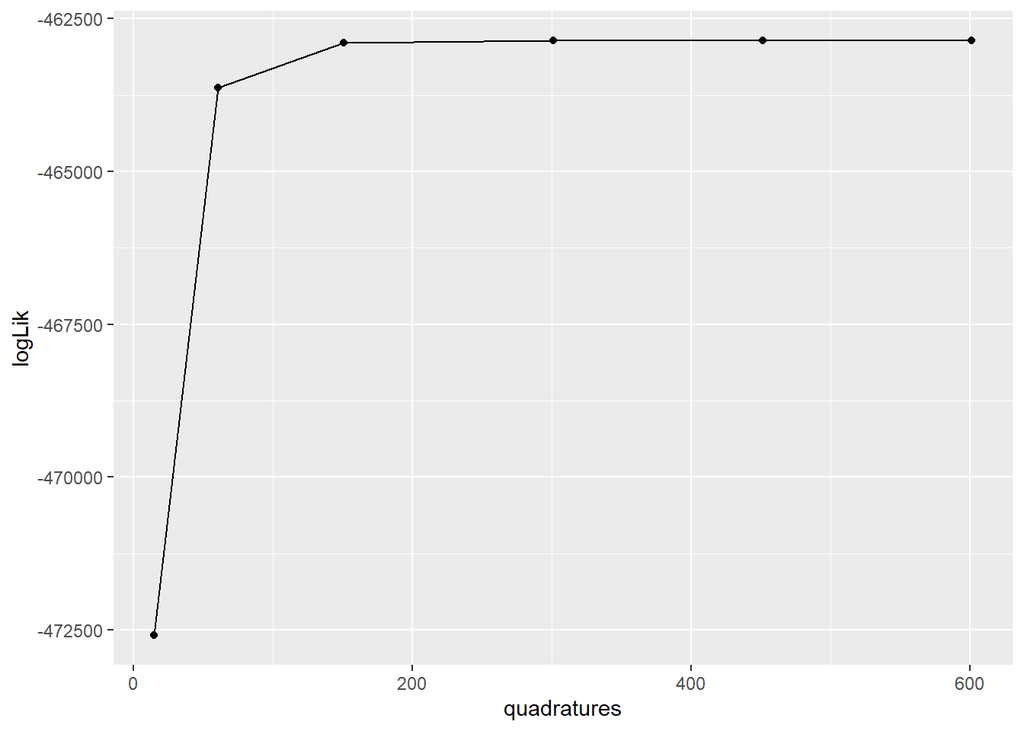

```r
ggplot(df, aes(quadratures, logLik)) +
  geom_point() +
  geom_line()
```

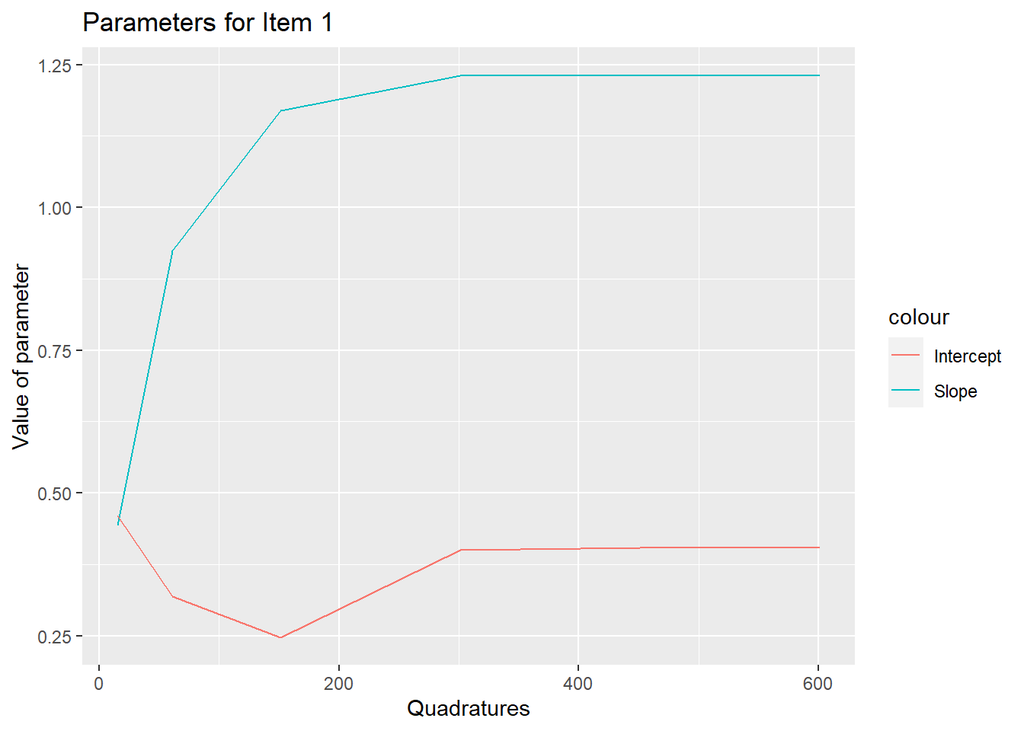

```r
ggplot(df, aes(quadratures)) +
  geom_line(aes(y = a1_1, colour = "Slope")) +
  geom_line(aes(y = d_1, colour = "Intercept")) +
  xlab("Quadratures") +
  ylab("Value of parameter") +
  labs(title = "Parameters for Item 1")
```

## TAM default settings (quasi Monte Carlo integration)

```r
tam_model <- tam.mml.2pl(responses, irtmodel="2PL")
```

```r
tam_model
```

```
## TAM 3.7-16 (2021-06-24 14:31:37)
##
## Call:
## tam.mml.2pl(resp = responses, irtmodel = "2PL")
##
## Multidimensional Item Response Model in TAM
##
## Deviance= 937694.3  | Log Likelihood= -468847.2
## Number of persons used= 2297
## Number of estimated parameters= 1340
## AIC= 940374
## BIC= 948065
```

```r
tam_params<-data.frame(a1=tam_model$item[,"B.Cat1.Dim1"], d=tam_model$xsi$xsi)
head(tam_params)
```

```
##          a1          d
## 1 0.5170107 -0.4429237
## 2 0.6169342 -2.9733721
## 3 0.5331953 -2.1666731
## 4 0.6504970 -1.5520617
## 5 0.6340160 -2.8634124
## 6 0.5651001 -1.6952350
```

Results are quite similar to ltm’s default settings. Difficulty’s sign just has to be changed for some reason (https://www.researchgate.net/publication/328968604_Evaluation_of_R_Packages_with_IRT_2PL_Model)

## TAM 201 snodes - “ordinary” stochastic integration

I believe this snodes (“number of simulated θ nodes for stochastic integration”, https://cran.r-project.org/web/packages/TAM/TAM.pdf, p.115) is some equivalent for quadratures.

```r
tam_model <- tam.mml.2pl(responses, irtmodel="2PL", control=list(snodes = 201, QMC=FALSE)
```

```r
tam_model
```

[output not shown]

```r
tam_params<-data.frame(a1=tam_model$item[,"B.Cat1.Dim1"], d=tam_model$xsi$xsi)
head(tam_params)
```

```
##         a1          d
## 1 1.290692 -0.4361735
## 2 1.451109 -2.9353086
## 3 1.301972 -2.1602121
## 4 1.603556 -1.5350817
## 5 1.488432 -2.8190486
## 6 1.372905 -1.6772244
```

## TAM 301 snodes

```r
tam_model <- tam.mml.2pl(responses, irtmodel="2PL", control=list(snodes = 301, QMC=FALSE))
```

```r
tam_model
```

```
## TAM 3.7-16 (2021-06-24 14:31:37)
##
## Call:
## tam.mml.2pl(resp = responses, irtmodel = "2PL", control = list(snodes = 301,
##     QMC = FALSE))
##
## Multidimensional Item Response Model in TAM
##
## Deviance= 925743.4  | Log Likelihood= -462871.7
## Number of persons used= 2297
## Number of estimated parameters= 1340
## AIC= 928423
## BIC= 936114
```

```r
tam_params<-data.frame(a1=tam_model$item[,"B.Cat1.Dim1"], d=tam_model$xsi$xsi)
head(tam_params)
```

```
##         a1          d
## 1 1.207388 -0.2569013
## 2 1.307247 -2.7139736
## 3 1.203771 -1.9776100
## 4 1.500617 -1.3107544
## 5 1.357702 -2.6002946
## 6 1.275193 -1.4840308
```

## TAM 451 snodes

```r
tam_model <- tam.mml.2pl(responses, irtmodel="2PL", control=list(snodes = 451, QMC=FALSE))
```

```r
tam_model
```

[output not shown]

```r
tam_params<-data.frame(a1=tam_model$item[,"B.Cat1.Dim1"], d=tam_model$xsi$xsi)
head(tam_params)
```

```
##         a1          d
## 1 1.294069 -0.5353801
## 2 1.430887 -3.0339972
## 3 1.298054 -2.2585032
## 4 1.605324 -1.6566207
## 5 1.475829 -2.9259975
## 6 1.371197 -1.7807375
```

## Summary

### mirt

[output not shown]

a1 & d are params for 1st item

### ltm

| Quadratures | LogLik | a1 | d |
| --- | --- | --- | --- |
| 15 | -470030.7 | 0.5063 | 0.5008 |
| 61 | -466025.8 | 0.6275 | 0.3815 |
| 101 | -464945.3 | 0.6854 | 0.4937 |

### TAM

[output not shown]